# **Time Series Modeling**

Objective: Analyze and forecast unit sales for an Electronics category at an online retailer.

Process:

1) Plot total sales series and examine the main features of the graph, to determine whether there is

```
- a trend
- a seasonal component
- any apparent sharp changes in behavior
- any outlying observations
```

2) Remove the trend and seasonal components to get stationary residuals

3) Forecast the series leveraging ARIMA model

4) Forecast sales for an item with Scikit Learn - Random Forest Regressor

```python
%matplotlib inline
import matplotlib.pyplot as plt
import numpy as np
import pandas as pd
import seaborn as sns
from sklearn.ensemble import RandomForestRegressor
from sklearn.model_selection import train_test_split
from sklearn import linear_model
from matplotlib.pylab import rcParams
rcParams['figure.figsize'] = 15, 6
```

```python
#Create function to test Stationarity of a Time Series and Analyze statistical data
import statsmodels.tsa.stattools
def test_stationarity(timeseries):

    #Determing rolling statistics
    rolmean = timeseries.rolling(window=12).mean()
    rolstd = timeseries.rolling(window=12).std()

    #Plot rolling statistics:
    orig = plt.plot(timeseries, color='blue',label='Original')
    mean = plt.plot(rolmean, color='red', label='Rolling Mean')
    std = plt.plot(rolstd, color='black', label = 'Rolling Std')
    plt.legend(loc='best')
    plt.title('Rolling Mean & Standard Deviation')
    plt.show(block=False)

    #Perform Dickey-Fuller test:
    print ('Results of Dickey-Fuller Test:')
    dftest = statsmodels.tsa.stattools.adfuller(timeseries.values, autolag='AIC')
    dfoutput = pd.Series(dftest[0:4], index=['Test Statistic','p-value','#Lags Used','Number of Observations Used'])
    for key,value in dftest[4].items():
        dfoutput['Critical Value (%s)'%key] = value
    print (dfoutput)
```

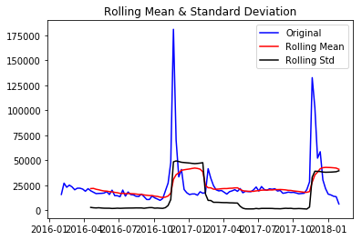

```
Results of Dickey-Fuller Test:
Test Statistic                  -5.545739
p-value                          0.000002
#Lags Used                       0.000000
Number of Observations Used    104.000000
Critical Value (1%)             -3.494850
Critical Value (5%)             -2.889758
Critical Value (10%)            -2.581822
dtype: float64
```

```python
#Plotting rolling statistics: It is clear that there is a seasonality seen in Spring (Tax season)
# and fourth quarter (holiday sales)
test_stationarity(ts)
```

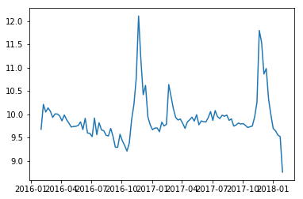

```python
# Making the time series stationary to be able to forecast it better, by removing seasonality and trend.
# The usual procedure is to first filter out the trend and seasonal component
# then fit the random component with a stationary time series model to
# capture the correlation structure in the time series

# First: use numpy's log function and see the trend in the time series

#As we can see there is remarakble seasonality spikes in the fourth quarters (weeks 40-50) that
# will need to be smoothed

ts_log = np.log(ts)
plt.plot(ts_log)
```

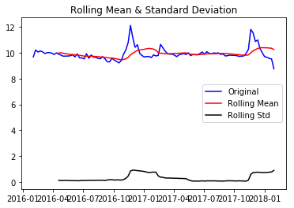

```
Results of Dickey-Fuller Test:
Test Statistic                  -4.482081
p-value                          0.000212
#Lags Used                       3.000000
Number of Observations Used    101.000000
Critical Value (1%)             -3.496818
Critical Value (5%)             -2.890611
Critical Value (10%)            -2.582277
dtype: float64
```

```python
test_stationarity(ts_log)
```

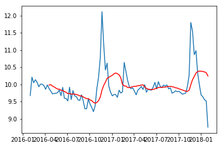

```python
#Plot moving average, notice the moving average is higher on the second year indicating an upwards trend
moving_avg = ts_log.rolling(window=12).mean()
plt.plot(ts_log)
plt.plot(moving_avg, color='red')
```

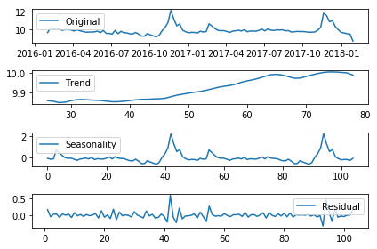

```python
#Extrapolate trend, seasonality and residual

from statsmodels.tsa.seasonal import seasonal_decompose
import statsmodels.api as sm

# ts_log_series = pd.Series([x%3 for x in range (100)])

decomposition = sm.tsa.seasonal_decompose(ts_log.values, freq=52)

trend = decomposition.trend
seasonal = decomposition.seasonal
residual = sm.tsa.seasonal_decompose(ts_log.values, freq=2).resid

plt.subplot(411)
plt.plot(ts_log, label='Original')
plt.legend(loc='best')
plt.subplot(412)
plt.plot(trend, label='Trend')
plt.legend(loc='best')
plt.subplot(413)
plt.plot(seasonal,label='Seasonality')
plt.legend(loc='best')
plt.subplot(414)
plt.plot(residual, label='Residual')
plt.legend(loc='best')
plt.tight_layout()
```

|  | Percent lift |
| --- | --- |
| 0 | NaN |
| 1 | 16.021471 |
| 2 | -4.864543 |
| 3 | 2.588636 |
| 4 | 2.920788 |
| 5 | -6.609615 |
| 6 | 3.351773 |
| 7 | -0.461945 |
| 8 | 3.071455 |
| 9 | -7.224405 |

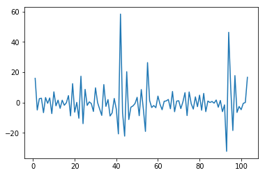

```python
#Examing residual fluctuations (noise)
residual_fluctuations = pd.DataFrame(residual*100)
residual_fluctuations.columns=["Percent lift"]
plt.plot(residual_fluctuations)
residual_fluctuations.head(10)
```

|  | Percent lift |
| --- | --- |
| 0 | -6.400474 |
| 1 | -15.184921 |
| 2 | -12.265616 |
| 3 | 72.305172 |
| 4 | 45.750334 |
| 5 | 19.404375 |
| 6 | -0.078846 |
| 7 | -6.399686 |
| 8 | -4.952946 |
| 9 | -14.819376 |

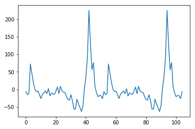

```python
# Extrapolate seaonality builds to be used later
seasonal_lifts = pd.DataFrame(seasonal*100)
seasonal_lifts.columns=["Percent lift"]
plt.plot(seasonal_lifts)
seasonal_lifts.head(10)
```

Notes:

```
- Seasonality shows a lift of 200+% during holiday spikes
- Residuals show a lift of ~60% the week before the major seasonality spikes
```

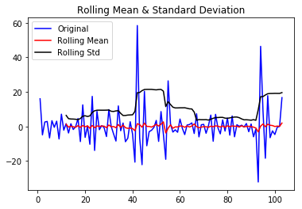

```python
#Test stationarity over residual (noise) fluctuations
ts_log_decompose = residual_fluctuations
ts_log_decompose.dropna(inplace=True)
test_stationarity1(ts_log_decompose)
```

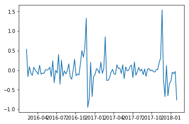

```python
#Differencing in statistics is a transformation applied to time-series data in order to make it stationary
# A stationary time series' properties do not depend on the time at which the series is observed.(https://en.wikipedia.org/wiki/Autoregressive_integrated_moving_average).
ts_log_diff = ts_log - ts_log.shift()
plt.plot(ts_log_diff)
```

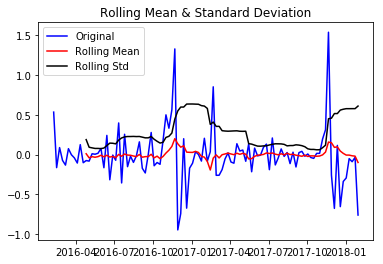

```python
test_stationarity1(ts_log_diff)
```

```
<function matplotlib.pyplot.plot>
```

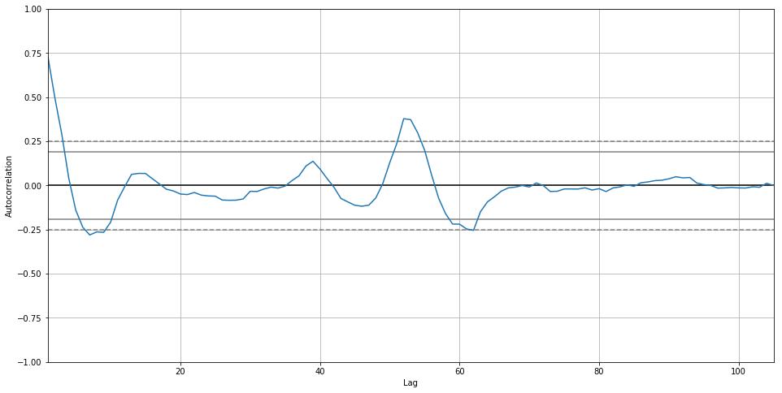

```python
from pandas.plotting import autocorrelation_plot

plt.figure(figsize=(16,8))
autocorrelation_plot(ts_log)
plt.plot
```

**ARIMA**

ARIMA is an acronym that stands for AutoRegressive Integrated Moving Average:

- AR: Autoregression. A model that uses the dependent relationship between an observation and some number of lagged observations.
- I: Integrated. The use of differencing of raw observations (e.g. subtracting an observation from an observation at the previous time step) in order to make the time series stationary.
- MA: Moving Average. A model that uses the dependency between an observation and a residual error from a moving average model applied to lagged observations.

Each of these components are explicitly specified in the model as a parameter. A standard notation is used of ARIMA(p,d,q) where the parameters are substituted with integer values to quickly indicate the specific ARIMA model being used.

The parameters of the ARIMA model are defined as follows:

- p: The number of lag observations included in the model, also called the lag order.
- d: The number of times that the raw observations are differenced, also called the degree of differencing.
- q: The size of the moving average window, also called the order of moving average.

Source: https://machinelearningmastery.com/arima-for-time-series-forecasting-with-python/

```python
from statsmodels.tsa.arima_model import ARIMA

AR_model = ARIMA(ts_log, order=(0,1,5))
results_AR = AR_model.fit(disp=-1)
print(results_AR.summary())

# The coef column shows the weight (i.e. importance) of each feature and how each one impacts the time series.
# The P>|z| column informs us of the significance of each feature weight.
# We want a p-value lower or close to 0.05
```

```
                             ARIMA Model Results
==============================================================================
Dep. Variable:                D.Units   No. Observations:                  104
Model:                 ARIMA(0, 1, 5)   Log Likelihood                 -23.254
Method:                       css-mle   S.D. of innovations              0.297
Date:                Sun, 08 Jul 2018   AIC                             60.508
Time:                        12:02:39   BIC                             79.019
Sample:                    02-08-2016   HQIC                            68.008
                         - 01-29-2018
=================================================================================
                    coef    std err          z      P>|z|      [0.025      0.975]
---------------------------------------------------------------------------------
const             0.0013      0.003      0.429      0.669      -0.005       0.007
ma.L1.D.Units    -0.1861      0.097     -1.914      0.059      -0.377       0.004
ma.L2.D.Units    -0.2348      0.092     -2.543      0.013      -0.416      -0.054
ma.L3.D.Units     0.0568      0.116      0.488      0.627      -0.171       0.285
ma.L4.D.Units    -0.2642      0.083     -3.184      0.002      -0.427      -0.102
ma.L5.D.Units    -0.3717      0.108     -3.428      0.001      -0.584      -0.159
                                    Roots
=============================================================================
                 Real           Imaginary           Modulus         Frequency
-----------------------------------------------------------------------------
MA.1            1.0000           -0.0000j            1.0000           -0.0000
MA.2            0.3596           -1.1493j            1.2042           -0.2017
MA.3            0.3596           +1.1493j            1.2042            0.2017
MA.4           -1.2149           -0.6157j            1.3620           -0.4253
MA.5           -1.2149           +0.6157j            1.3620            0.4253
-----------------------------------------------------------------------------
```

```python
forecast = pd.Series(results_AR.forecast())
print(forecast)
```

```
0                     [9.08570042636]
1                    [0.297295018062]
2    [[8.50301289818, 9.66838795455]]
dtype: object
```

```
                0
count  104.000000
mean     0.003107
std      0.302689
min     -0.815853
25%     -0.146085
50%     -0.030146
75%      0.087723
max      1.586472
```

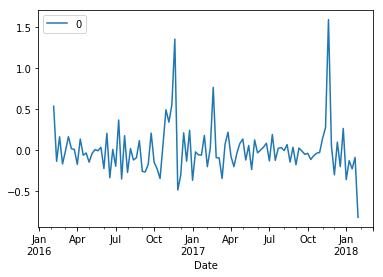

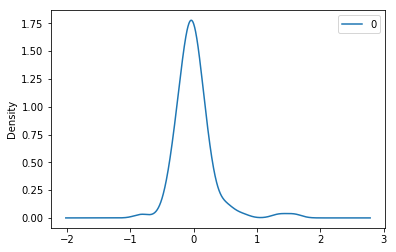

```python
# plot residual errors
residuals = pd.DataFrame(results_AR.resid)
residuals.plot()
residuals.plot(kind='kde')
print(residuals.describe())
```

```
Text(0.5,1,'ARIMA forecast vs. Stationary Values')
```

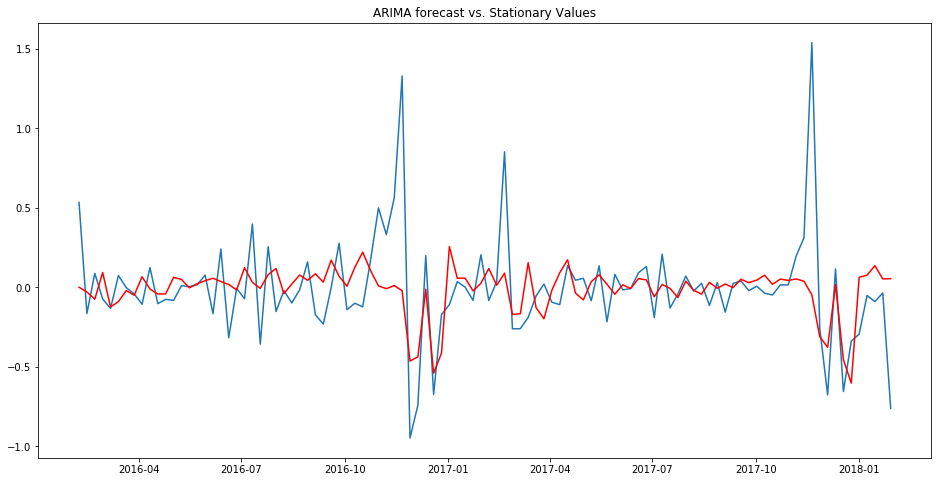

```python
plt.figure(figsize=(16,8))
plt.plot(ts_log_diff)
plt.plot(results_AR.fittedvalues, color='red')
plt.title('ARIMA forecast vs. Stationary Values')
```